# GWAS for OCT (RNFL) Measures in CHES and LALES

Prepared by Darryl Nousome

August 11, 2017

Details: GWAS was performed in CHES and LALES separately and also combined through Meta-Analysis using the Inverse Variance Weighted Method. After QC there are n=2322 LALES and n=1672 CHES participants.

Each study used the same QC and analysis methods. QC was performed where SNPs were retained on MAF >0.05 and Info >0.4. This leaves ~1808320 SNPs to analyze in CHES and ~7017540 in LALES depending on the various measures.

SNPs were modeled in a log-additive model in a linear regression model adjusting for Age, Gender, Signal Strength, and PC1-PC3, after scaling/centering.

### LALES-Average RNFL

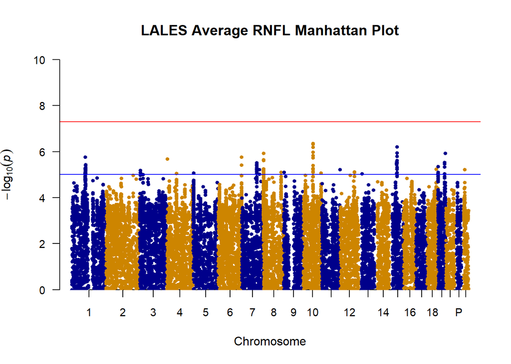

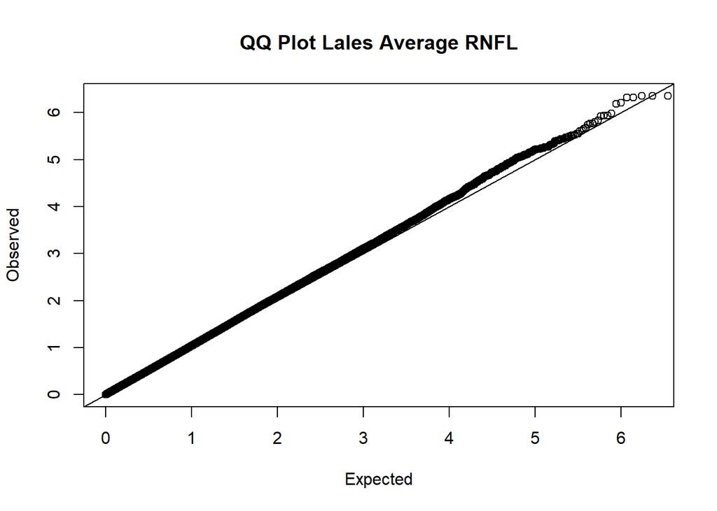

Likely due to including related individuals we will use only those that are unrelated in our sample, by pruning indiviudals via PI HAT, where those with PIHAT<0.5, in our sample are included. This dropped the sample size to 2218 in LALES. The other method is to use account for kinship in the model (like EMMAX-Efficient Mixed-Model Association eXpedited).

### LALES-Average RNFL, using unrelateds only

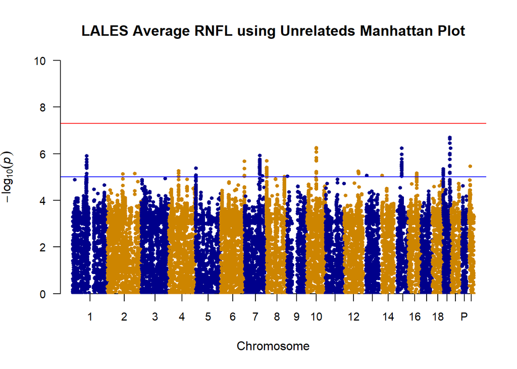

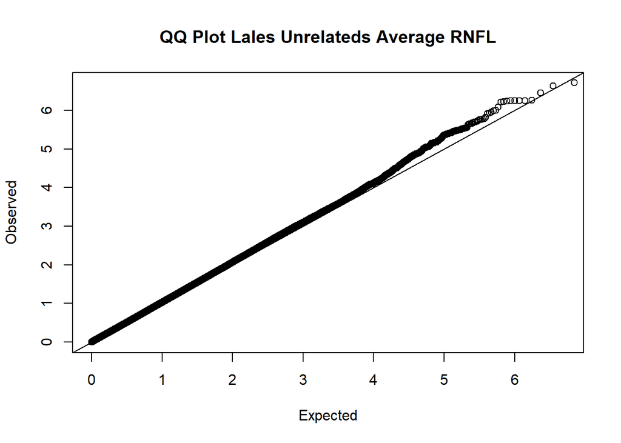

### CHES-Average RNFL

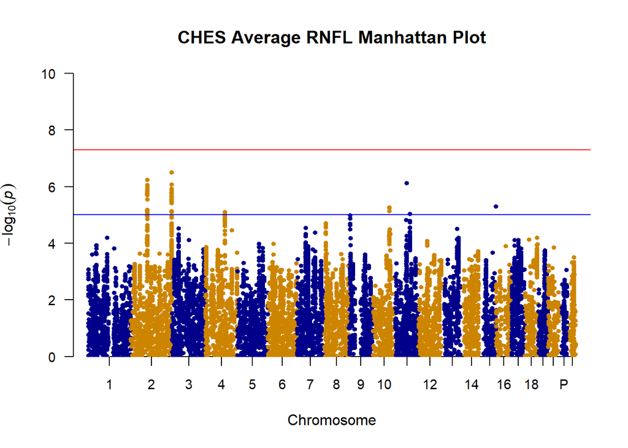

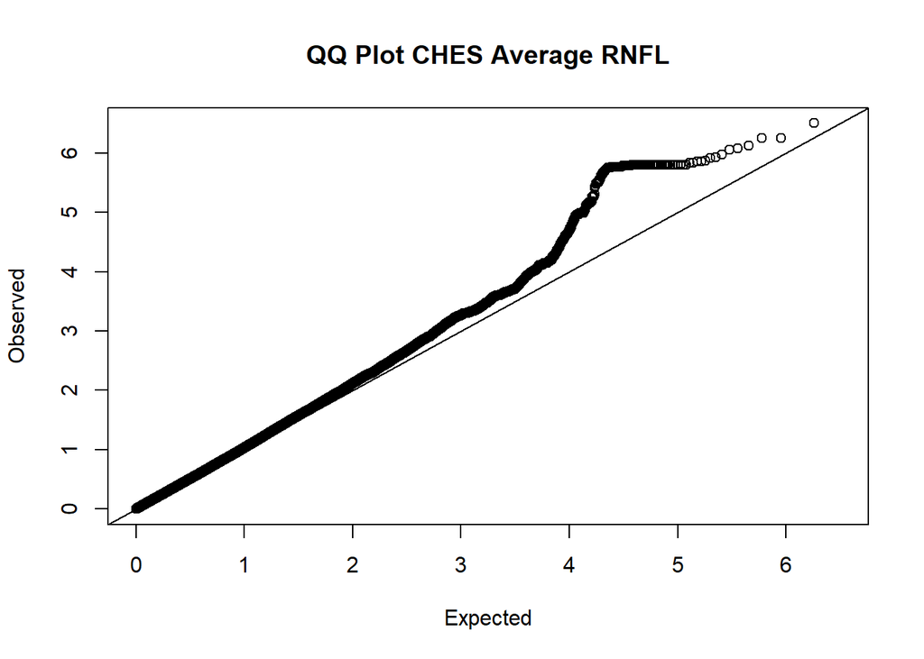

### Meta-Analysis of Average RNFL

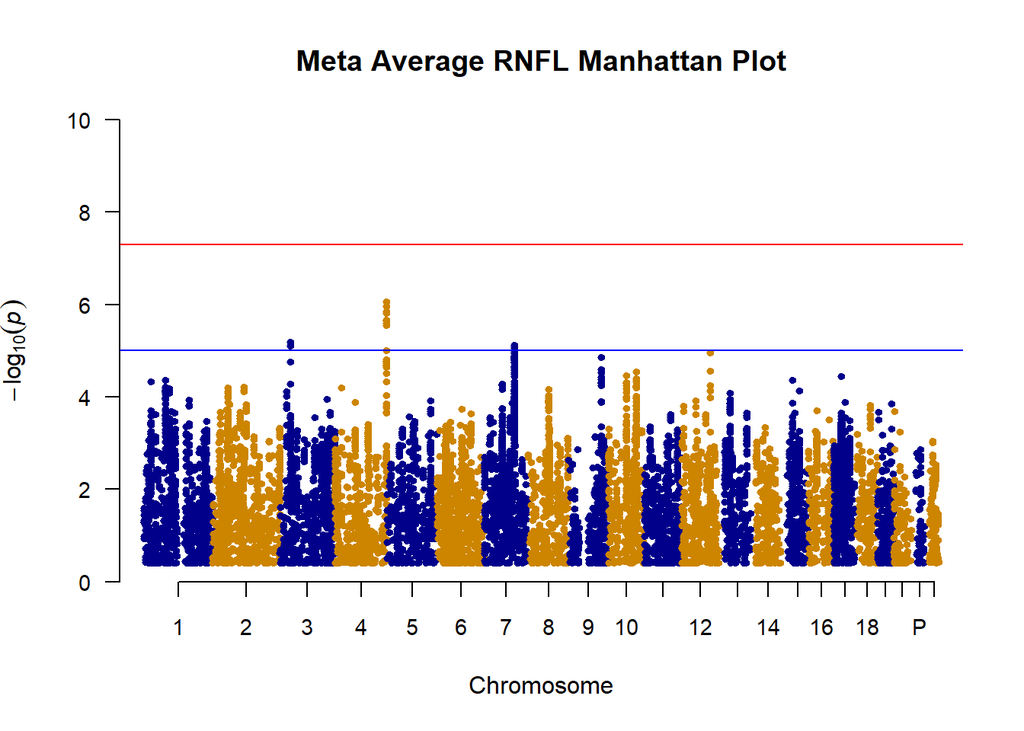

## LALES-Nasal RNFL, unrelateds

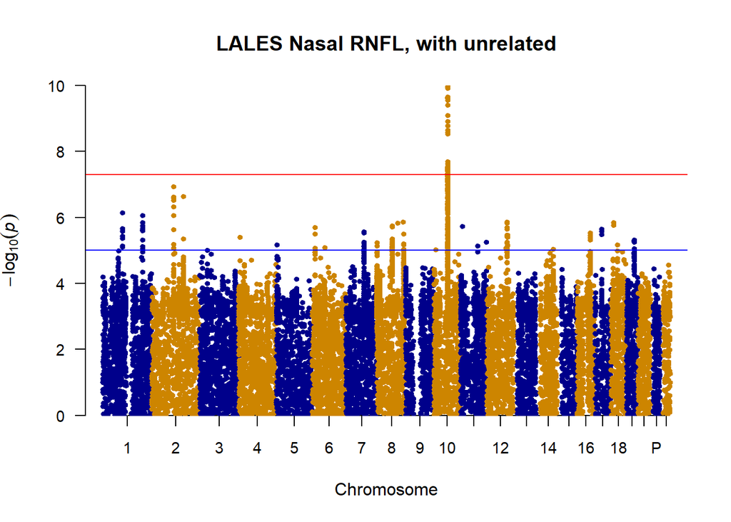

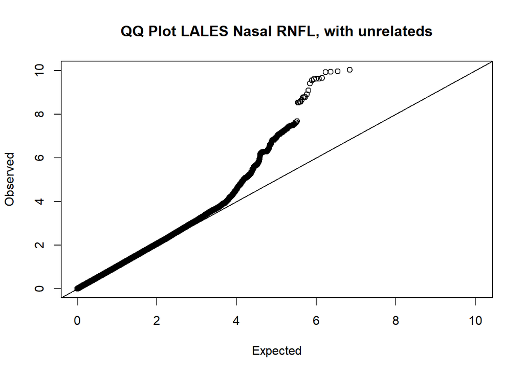

### LALES-Nasal RNFL,using EMMAX

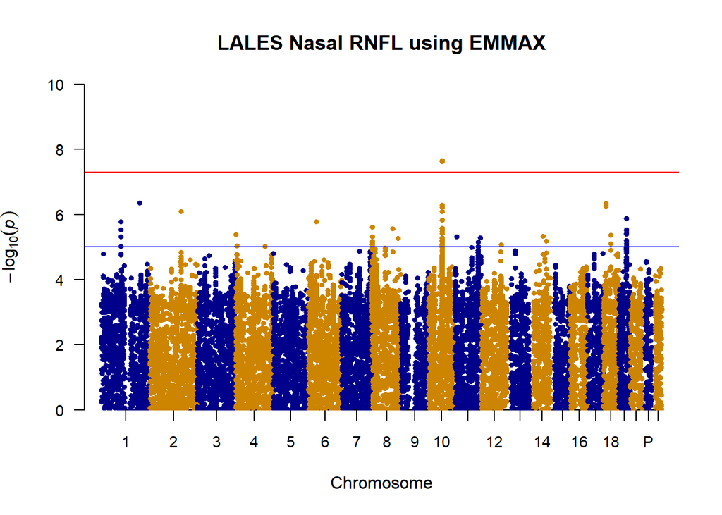

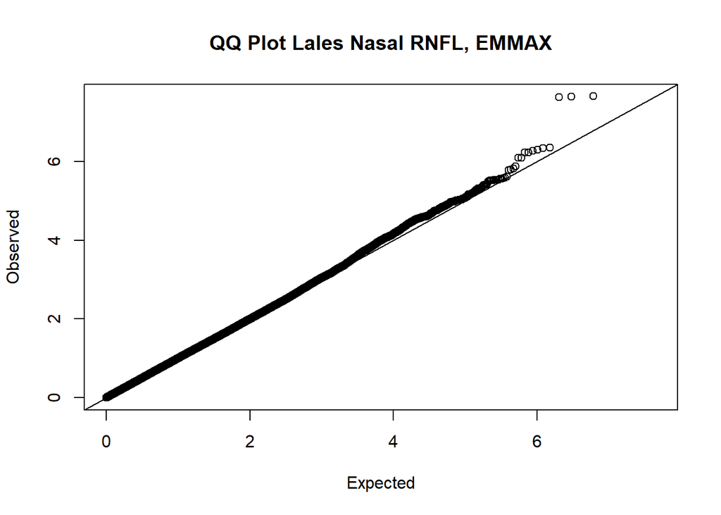

EMMAX methods appear to control for relatedness better than using unrelated with likely more power.

## CHES-Nasal RNFL

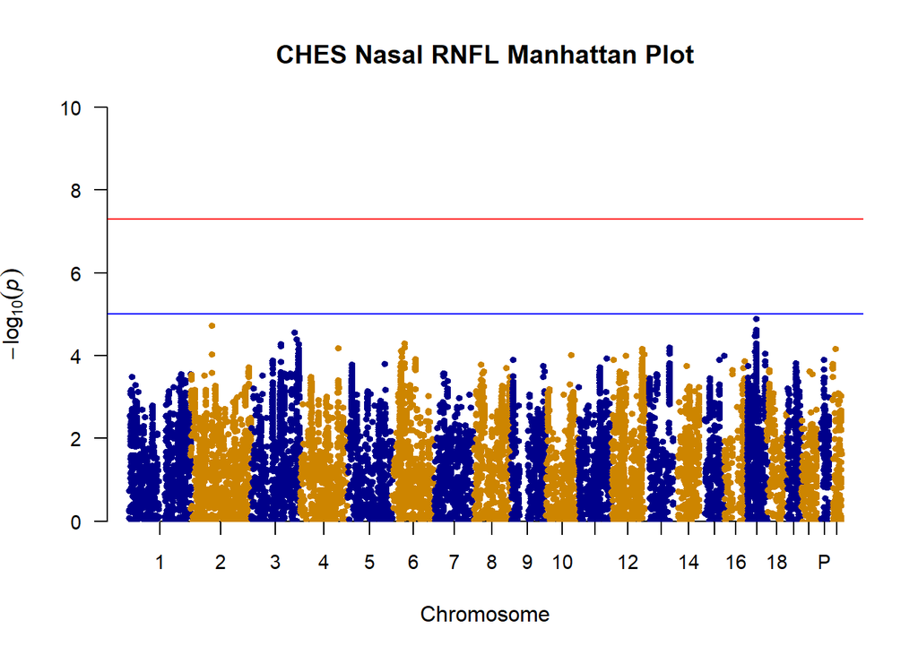

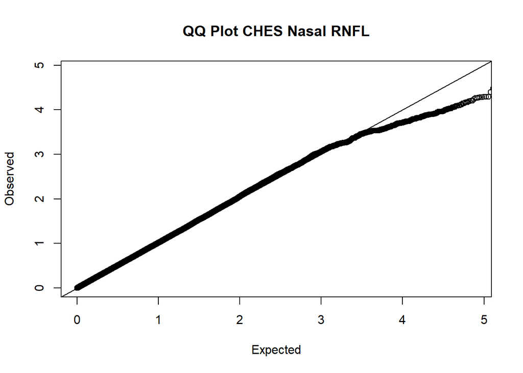

### Meta-Analysis of Nasal RNFL

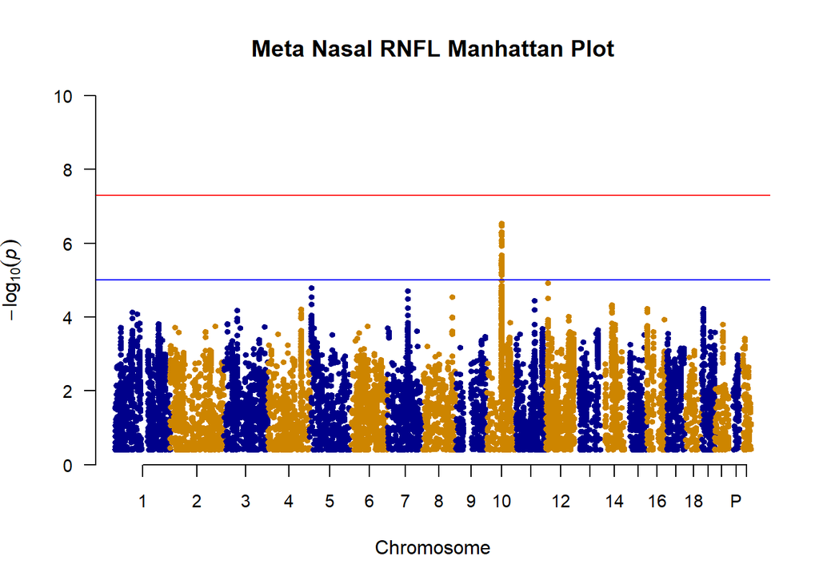

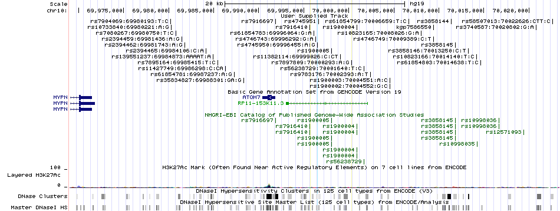

Previous hits include those with VCDR.

### LALES-Superior RNFL,using EMMAX

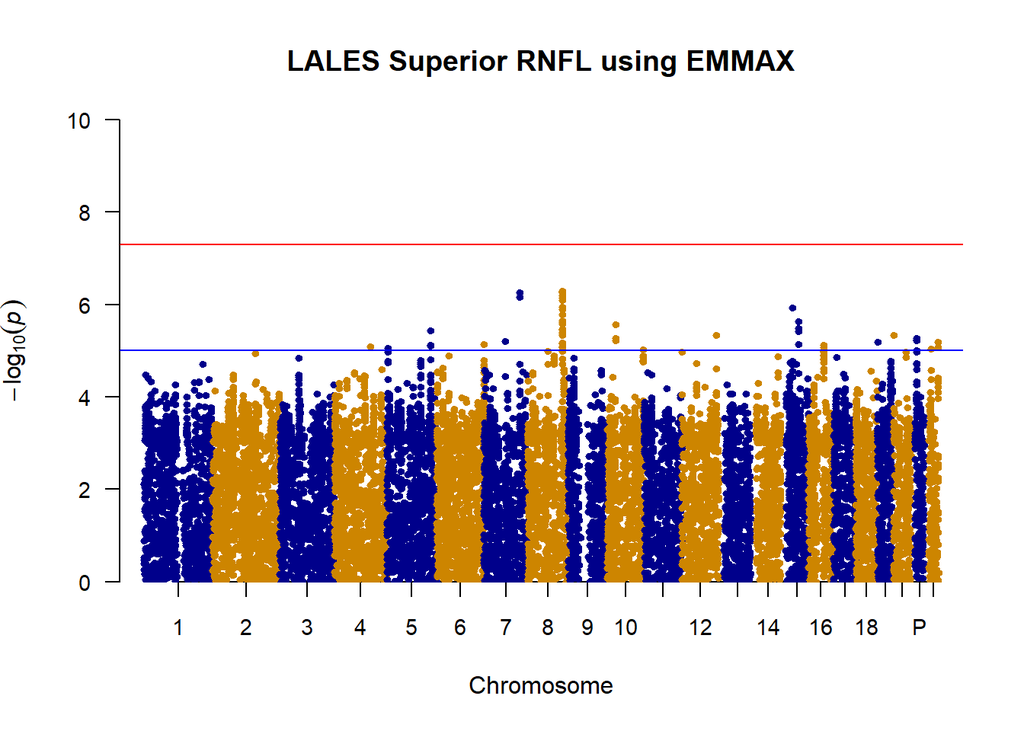

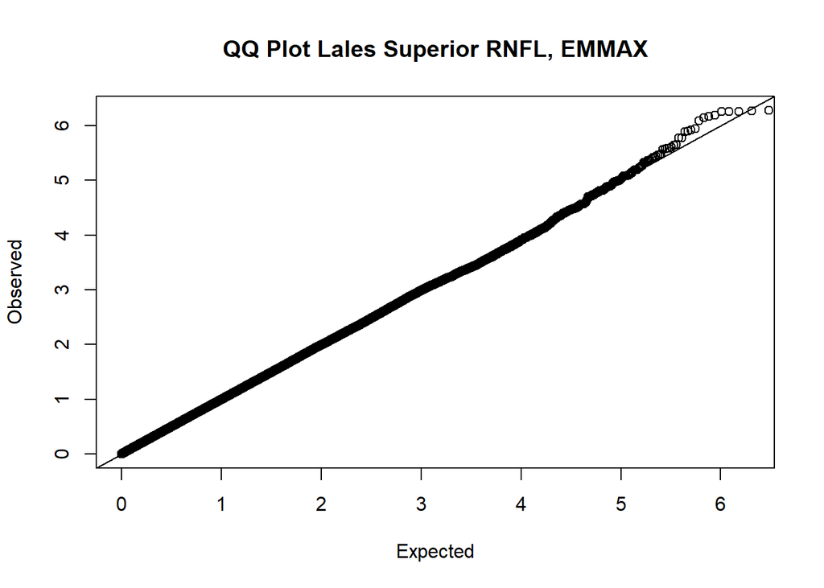

## CHES-Superior RNFL

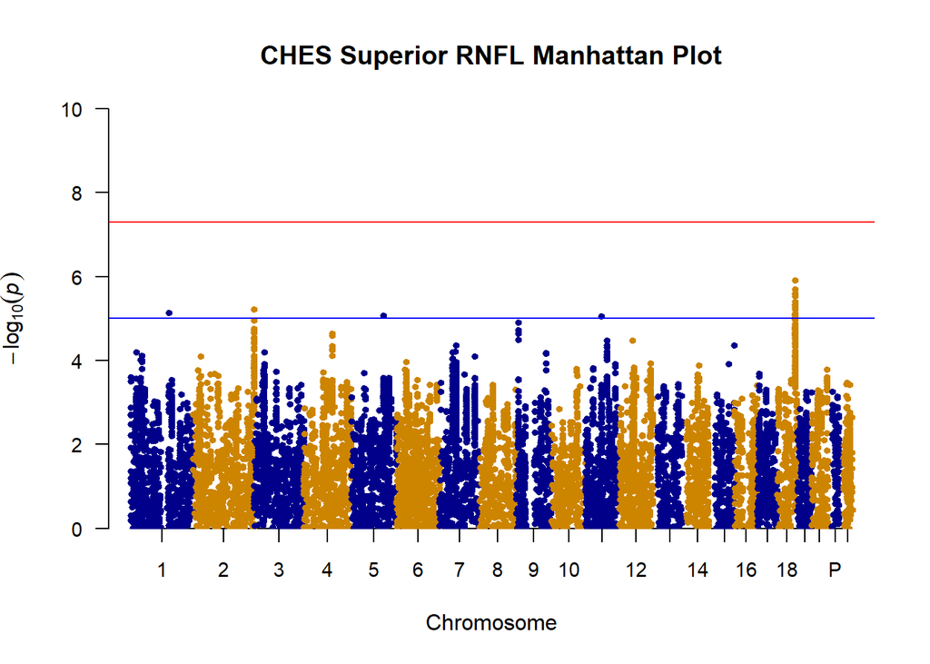

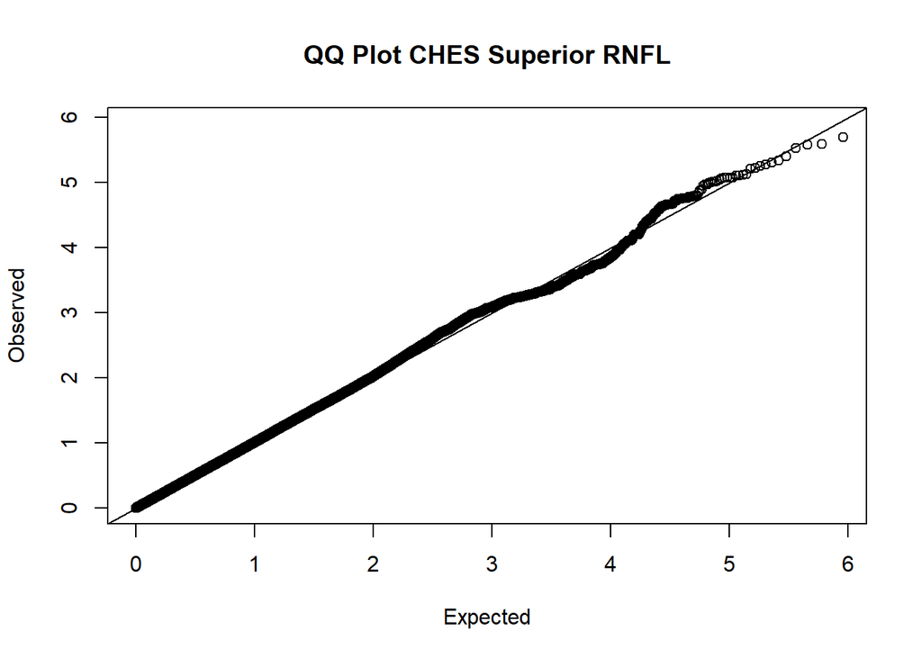

### Meta-Analysis of Superior RNFL

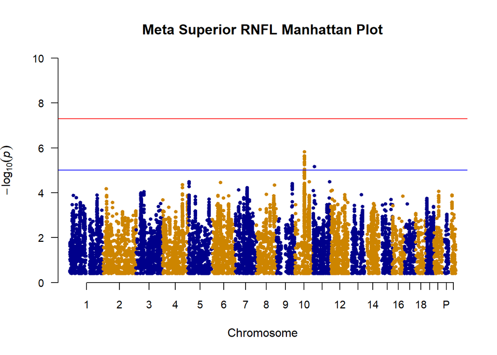